# CREDIT SCORING ALGORITHM

*Aureliana Winarto*

```python
#TOOGLE ALL INPUTS
from IPython.display import HTML

HTML('''<script>
code_show=true;
function code_toggle() {
 if (code_show){
 $('div.input').hide();
 } else {
 $('div.input').show();
 }
 code_show = !code_show
}
$( document ).ready(code_toggle);
</script>
The raw code for this IPython notebook is by default hidden for easier reading.
To toggle on/off the raw code, click <a href="javascript:code_toggle()">here</a>.''')
```

The raw code for this IPython notebook is by default hidden for easier reading. To toggle on/off the raw code, click here.

1. Objective

2. Features

3. Modelling: Data Overview; Data Preprocessing; Choice of Predictive Model; Analysis on Model's Performance

4. Conclusion

## 1. Objective

This excerpt aims to go through the steps on modelling a particular credit scoring algorithm based on available data comprising several relevant features.

## 2. Features

Features and their descriptions are as follows:

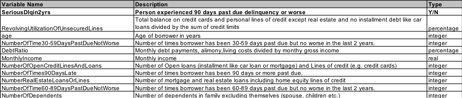

```python
from IPython.display import Image
Image('/Users/aurelianawinarto/Documents/WORK STUFF/Graduate/Taralite/CASE STUDY/Images/features.png')
```

SeriousDlqin2yrs is thus the output to be assessed and the rest are inputs for the credit score modelling. For the purpose of this activity, Y/N is then translated to 1/0. A value of closer to 1 indicates more probability of default, whereas value of closer to 0 implies less probability of default.

According to Fair Isaac and Co. (FICO), the most widely used credit score worldwide, the contribution of each component to the credit score is as follows:

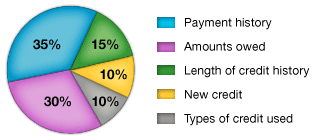

```python
Image('/Users/aurelianawinarto/Documents/WORK STUFF/Graduate/Taralite/CASE STUDY/Images/FICO-Score-Factors.png')
```

[figure not shown]

```python
Image('/Users/aurelianawinarto/Documents/WORK STUFF/Graduate/Taralite/CASE STUDY/Images/FICO-Scoring-Model-e1335744261617.png')
```

The pictures above are for reference purpose only, which may help to explain the datasets as below:

- Payment History: may refer to variables NumberOfTime30-59DaysPastDueNotWorse, NumberOfTimes90DaysLate, and NumberOfTime60-89PastDueNotWorse. No derogatory public record serves the highest score. In case there is one, shorter time since the last record gets lower score and reverse is also true for the opposite.
- Outstanding Debt: may be related to RevolvingUtilizationOfUnsecuredLines and DebtRatio. A healthy credit with the highest score implies a medium amount of borrowing - not too high or too low.
- Credit History Length: no variables in the dataset corresponding to this item.
- Pursuit of New Credit: no variables in the dataset corresponding to this item.
- Types of credit used / Credit Mix: may correspond to NumberOfOpenCreditLinesAndLoans and NumberRealEstateLoansOrLines. Like Outstanding Debt, a medium number of this item obtains the highest credit score.

FICO also states that they do not take Age, MonthlyIncome, and NumberOfDependents into consideration. However, they will still be included in the model with the following potential relationship:

- Age: older person of the working age might mean higher credit score as a result of more well-established financial situation.
- MonthlyIncome: the more the income, the more the ability to meet obligations and thus the higher score.
- NumberOfDependents: medium number of dependents may be assumed to imply higher score due to the existence of but not excessive number of credit taken.

## 3. Modelling

```python
#CODES: FOR REFERENCE ONLY

#import
import numpy as np
import pandas as pd
import matplotlib.pyplot as plt
import seaborn as sns

plt.style.use("fivethirtyeight")

#change directory
import os
os.chdir('/Users/aurelianawinarto/Documents/WORK STUFF/Graduate/Taralite/CASE STUDY/Data')
```

```python
#2: upload files
test_data = pd.read_csv('cs-test.csv')
train_data = pd.read_csv('cs-training.csv')

#drop unnecessary variable
train_data = train_data.drop('Unnamed: 0', axis = 1)
test_data = test_data.drop('Unnamed: 0', axis = 1)
```

### Data Overview

This section provides brief insights regarding both Training and Test Data for the Credit Scoring Algorithm modelling.

#### Training Data

```python
train_data.info()
```

```
<class 'pandas.core.frame.DataFrame'>
RangeIndex: 150000 entries, 0 to 149999
Data columns (total 11 columns):
SeriousDlqin2yrs                        150000 non-null int64
RevolvingUtilizationOfUnsecuredLines    150000 non-null float64
age                                     150000 non-null int64
NumberOfTime30-59DaysPastDueNotWorse    150000 non-null int64
DebtRatio                               150000 non-null float64
MonthlyIncome                           120269 non-null float64
NumberOfOpenCreditLinesAndLoans         150000 non-null int64
NumberOfTimes90DaysLate                 150000 non-null int64
NumberRealEstateLoansOrLines            150000 non-null int64
NumberOfTime60-89DaysPastDueNotWorse    150000 non-null int64
NumberOfDependents                      146076 non-null float64
dtypes: float64(4), int64(7)
memory usage: 12.6 MB
```

```python
train_data.describe()
```

|  | SeriousDlqin2yrs | RevolvingUtilizationOfUnsecuredLines | age | NumberOfTime30-59DaysPastDueNotWorse | DebtRatio | MonthlyIncome | NumberOfOpenCreditLinesAndLoans | NumberOfTimes90DaysLate | NumberRealEstateLoansOrLines | NumberOfTime60-89DaysPastDueNotWorse | NumberOfDependents |
| --- | --- | --- | --- | --- | --- | --- | --- | --- | --- | --- | --- |
| count | 150000.000000 | 150000.000000 | 150000.000000 | 150000.000000 | 150000.000000 | 1.202690e+05 | 150000.000000 | 150000.000000 | 150000.000000 | 150000.000000 | 146076.000000 |
| mean | 0.066840 | 6.048438 | 52.295207 | 0.421033 | 353.005076 | 6.670221e+03 | 8.452760 | 0.265973 | 1.018240 | 0.240387 | 0.757222 |
| std | 0.249746 | 249.755371 | 14.771866 | 4.192781 | 2037.818523 | 1.438467e+04 | 5.145951 | 4.169304 | 1.129771 | 4.155179 | 1.115086 |
| min | 0.000000 | 0.000000 | 0.000000 | 0.000000 | 0.000000 | 0.000000e+00 | 0.000000 | 0.000000 | 0.000000 | 0.000000 | 0.000000 |
| 25% | 0.000000 | 0.029867 | 41.000000 | 0.000000 | 0.175074 | 3.400000e+03 | 5.000000 | 0.000000 | 0.000000 | 0.000000 | 0.000000 |
| 50% | 0.000000 | 0.154181 | 52.000000 | 0.000000 | 0.366508 | 5.400000e+03 | 8.000000 | 0.000000 | 1.000000 | 0.000000 | 0.000000 |
| 75% | 0.000000 | 0.559046 | 63.000000 | 0.000000 | 0.868254 | 8.249000e+03 | 11.000000 | 0.000000 | 2.000000 | 0.000000 | 1.000000 |
| max | 1.000000 | 50708.000000 | 109.000000 | 98.000000 | 329664.000000 | 3.008750e+06 | 58.000000 | 98.000000 | 54.000000 | 98.000000 | 20.000000 |

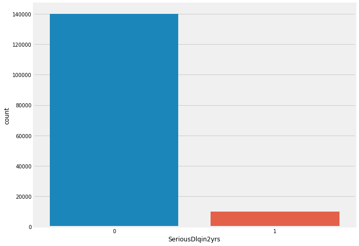

```python
#Distribution of target class
plt.figure(figsize=(10,8))
sns.countplot("SeriousDlqin2yrs", data=train_data)
```

```python
#Checking event rate
class_0 = train_data.SeriousDlqin2yrs.value_counts()[0]
class_1 = train_data.SeriousDlqin2yrs.value_counts()[1]
print("Total number of class_0: {}".format(class_0))
print("Total number of class_1: {}".format(class_1))
print("Event rate: {} %".format(class_1/(class_0+class_1) *100))
```

```
Total number of class_0: 139974
Total number of class_1: 10026
Event rate: 6.683999999999999 %
```

Problems identified in this training dataset include:

- Missing values indicated for MonthlyIncome and NumberOfDependents (i.e. less than 150000 non-null values).
- Age has outlier values of 0. These are assumed to be missing values.
- NumberOfTime30-59DaysPastDueNotWorse, NumberOfTimes90DaysLate, and NumberOfTime60-89DaysPastDueNotWorse generate awfully similar summary statistics. This may cause keeping more than one of these features to not provide any new information.
- Imbalanced target class; there are merely 6.68% training sets with SeriousDlqin2yrs value of 1.

#### Test Data

```python
test_data.info()
```

```
<class 'pandas.core.frame.DataFrame'>
RangeIndex: 101503 entries, 0 to 101502
Data columns (total 11 columns):
SeriousDlqin2yrs                        0 non-null float64
RevolvingUtilizationOfUnsecuredLines    101503 non-null float64
age                                     101503 non-null int64
NumberOfTime30-59DaysPastDueNotWorse    101503 non-null int64
DebtRatio                               101503 non-null float64
MonthlyIncome                           81400 non-null float64
NumberOfOpenCreditLinesAndLoans         101503 non-null int64
NumberOfTimes90DaysLate                 101503 non-null int64
NumberRealEstateLoansOrLines            101503 non-null int64
NumberOfTime60-89DaysPastDueNotWorse    101503 non-null int64
NumberOfDependents                      98877 non-null float64
dtypes: float64(5), int64(6)
memory usage: 8.5 MB
```

```python
test_data.describe()
```

|  | SeriousDlqin2yrs | RevolvingUtilizationOfUnsecuredLines | age | NumberOfTime30-59DaysPastDueNotWorse | DebtRatio | MonthlyIncome | NumberOfOpenCreditLinesAndLoans | NumberOfTimes90DaysLate | NumberRealEstateLoansOrLines | NumberOfTime60-89DaysPastDueNotWorse | NumberOfDependents |
| --- | --- | --- | --- | --- | --- | --- | --- | --- | --- | --- | --- |
| count | 0.0 | 101503.000000 | 101503.000000 | 101503.000000 | 101503.000000 | 8.140000e+04 | 101503.000000 | 101503.000000 | 101503.000000 | 101503.000000 | 98877.000000 |
| mean | NaN | 5.310000 | 52.405436 | 0.453770 | 344.475020 | 6.855036e+03 | 8.453514 | 0.296691 | 1.013074 | 0.270317 | 0.769046 |
| std | NaN | 196.156039 | 14.779756 | 4.538487 | 1632.595231 | 3.650860e+04 | 5.144100 | 4.515859 | 1.110253 | 4.503578 | 1.136778 |
| min | NaN | 0.000000 | 21.000000 | 0.000000 | 0.000000 | 0.000000e+00 | 0.000000 | 0.000000 | 0.000000 | 0.000000 | 0.000000 |
| 25% | NaN | 0.030131 | 41.000000 | 0.000000 | 0.173423 | 3.408000e+03 | 5.000000 | 0.000000 | 0.000000 | 0.000000 | 0.000000 |
| 50% | NaN | 0.152586 | 52.000000 | 0.000000 | 0.364260 | 5.400000e+03 | 8.000000 | 0.000000 | 1.000000 | 0.000000 | 0.000000 |
| 75% | NaN | 0.564225 | 63.000000 | 0.000000 | 0.851619 | 8.200000e+03 | 11.000000 | 0.000000 | 2.000000 | 0.000000 | 1.000000 |
| max | NaN | 21821.000000 | 104.000000 | 98.000000 | 268326.000000 | 7.727000e+06 | 85.000000 | 98.000000 | 37.000000 | 98.000000 | 43.000000 |

Findings are as follows:

- Missing values also appear for both MonthlyIncome and NumberOfDependents (i.e. less than 101503 non-null values).
- Unlike the training data, output for the test data has not yet been produced. This is denoted by "NaN" on the cells corresponding to SeriousDlqin2yrs.

### Data Preprocessing

Preprocessing is first implemented into Training Data and subsequently Test Data. The explanation below corresponds to the Training Data.

#### 1. Imputation

One way of imputation or dealing with missing data values is by filling in the blanks with appropriate values such as mean, median, or mode. According to observation from the previous section, data necessary to be imputed are as follows:

- Age: Imputed using median.

```python
train_data.loc[train_data["age"] == 0, "age"] = train_data.age.median()
```

- MonthlyIncome: Firstly is separated to working age (18 to under 60) and senior (60 and over). However, it is crucial to initially identify whether the dataset involves people underaged (under 18) to assure a comprehensive assessment. Subsequently, missing data in each segment are imputed using each segment's mean.

```python
train_data.loc[train_data["age"] < 18]
```

|  | SeriousDlqin2yrs | RevolvingUtilizationOfUnsecuredLines | age | NumberOfTime30-59DaysPastDueNotWorse | DebtRatio | MonthlyIncome | NumberOfOpenCreditLinesAndLoans | NumberOfTimes90DaysLate | NumberRealEstateLoansOrLines | NumberOfTime60-89DaysPastDueNotWorse | NumberOfDependents |
| --- | --- | --- | --- | --- | --- | --- | --- | --- | --- | --- | --- |

The empty table above indicates that there are no data of people under the age of 18.

```python
age_working = train_data.loc[(train_data["age"] >= 18) & (train_data["age"] < 60)]
age_senior = train_data.loc[(train_data["age"] >= 60)]

train_data["MonthlyIncome"] = train_data["MonthlyIncome"].fillna(99999) #to avoid TypeError
train_data.loc[((train_data["age"] >= 18) & (train_data["age"] < 60)) & (train_data["MonthlyIncome"] == 99999), "MonthlyIncome"] = age_working.MonthlyIncome.mean()
train_data.loc[(train_data["age"] >= 60) & (train_data["MonthlyIncome"] == 99999), "MonthlyIncome"] = age_senior.MonthlyIncome.mean()
```

- NumberofDependents: Comprises only several values with each of their own counts as follows:

```python
train_data.NumberOfDependents.value_counts()
```

```
0.0     86902
1.0     26316
2.0     19522
3.0      9483
4.0      2862
5.0       746
6.0       158
7.0        51
8.0        24
9.0         5
10.0        5
13.0        1
20.0        1
Name: NumberOfDependents, dtype: int64
```

Data is highly skewed towards 0 (the mode), therefore imputation is done by filling in the mode.

```python
train_data["NumberOfDependents"] = train_data["NumberOfDependents"].fillna(0)
train_data["NumberOfDependents"] = train_data["NumberOfDependents"].astype('int64')
```

#### 2. Highly Correlated Features

Identifying significantly correlated variables is essential to avoid multicollinearity and to discard or modify features lacking of new information. Below is the correlation matrix of the features.

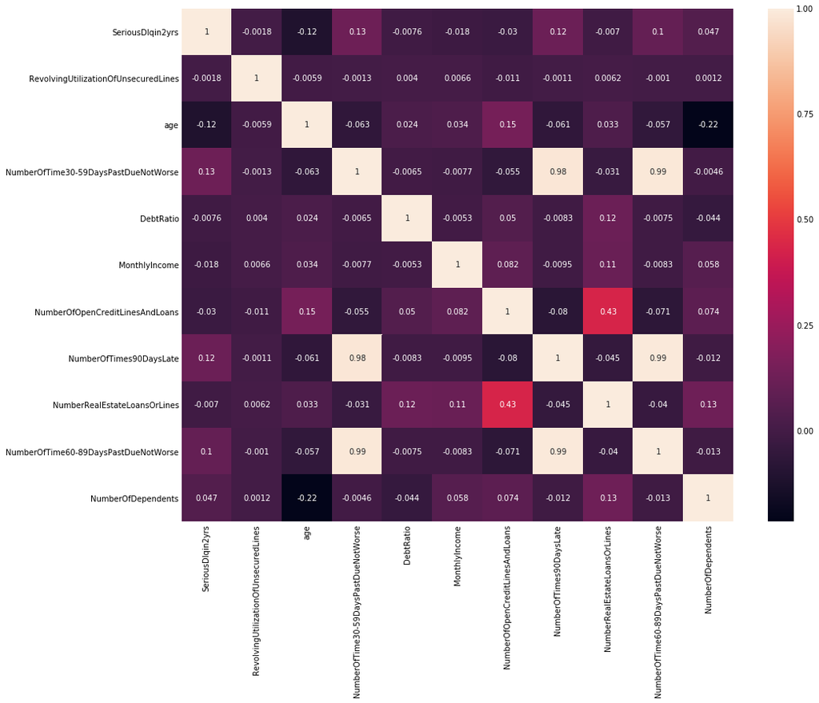

```python
corr = train_data.corr()
plt.figure(figsize=(14,12))
sns.heatmap(corr, annot=True, fmt=".2g")
```

Findings are as follows:

- NumberOfTime30-59DaysPastDueNotWorse, NumberOfTimes90DaysLate, and NumberOfTime60-89DaysPastDueNotWorse (number of late payments) are almost perfectly correlated, as expected from the observation in previous section.
- NumberOfOpenCreditLinesAndLoans and NumberRealEstateLoansOrLines (number of loans) are somewhat correlated.

One method to mitigate this situation is to modify by combining the correlated variables into one variable with a particular feature. Brief overview of above mentioned variables is laid out below:

```python
train_data["NumberOfTime30-59DaysPastDueNotWorse"].value_counts()
```

```
0     126018
1      16033
2       4598
3       1754
4        747
5        342
98       264
6        140
7         54
8         25
9         12
96         5
10         4
12         2
13         1
11         1
Name: NumberOfTime30-59DaysPastDueNotWorse, dtype: int64
```

```python
train_data["NumberOfTimes90DaysLate"].value_counts()
```

```
0     141662
1       5243
2       1555
3        667
4        291
98       264
5        131
6         80
7         38
8         21
9         19
10         8
11         5
96         5
13         4
12         2
14         2
15         2
17         1
Name: NumberOfTimes90DaysLate, dtype: int64
```

```python
train_data["NumberOfTime60-89DaysPastDueNotWorse"].value_counts()
```

```
0     142396
1       5731
2       1118
3        318
98       264
4        105
5         34
6         16
7          9
96         5
8          2
11         1
9          1
Name: NumberOfTime60-89DaysPastDueNotWorse, dtype: int64
```

```python
train_data["NumberOfOpenCreditLinesAndLoans"].value_counts()
```

```
6     13614
7     13245
5     12931
8     12562
4     11609
9     11355
10     9624
3      9058
11     8321
12     7005
2      6666
13     5667
14     4546
1      4438
15     3645
```

[output cut: 44 more lines]

```python
train_data["NumberRealEstateLoansOrLines"].value_counts()
```

```
0     56188
1     52338
2     31522
3      6300
4      2170
5       689
6       320
7       171
8        93
9        78
10       37
11       23
12       18
13       15
14        7
15        7
16        4
17        4
25        3
18        2
19        2
20        2
23        2
32        1
21        1
26        1
29        1
54        1
Name: NumberRealEstateLoansOrLines, dtype: int64
```

It is then decided to combine the three Late Payment features into one binary variable (having no late payment or having late payment) and the two Loan features into one binary variable (having five or less loans and having more than five loans).

```python
#combined late payments
train_data["CombinedLatePayment"] = train_data["NumberOfTime30-59DaysPastDueNotWorse"] + train_data["NumberOfTimes90DaysLate"] + train_data["NumberOfTime60-89DaysPastDueNotWorse"]
train_data.loc[(train_data["CombinedLatePayment"] >= 1), "CombinedLatePayment"] = 1

#combined loans
train_data["CombinedLoans"] = train_data["NumberOfOpenCreditLinesAndLoans"] + train_data["NumberRealEstateLoansOrLines"]
train_data.loc[(train_data["CombinedLoans"] <= 5), "CombinedLoans"] = 0
train_data.loc[(train_data["CombinedLoans"] > 5), "CombinedLoans"] = 1
```

The modified dataset and correlation matrix is then as follows:

```python
#dropping the old features
train_data.drop(["NumberOfTime30-59DaysPastDueNotWorse", "NumberOfTimes90DaysLate", "NumberOfTime60-89DaysPastDueNotWorse", "NumberOfOpenCreditLinesAndLoans","NumberRealEstateLoansOrLines"], axis = 1, inplace = True)
```

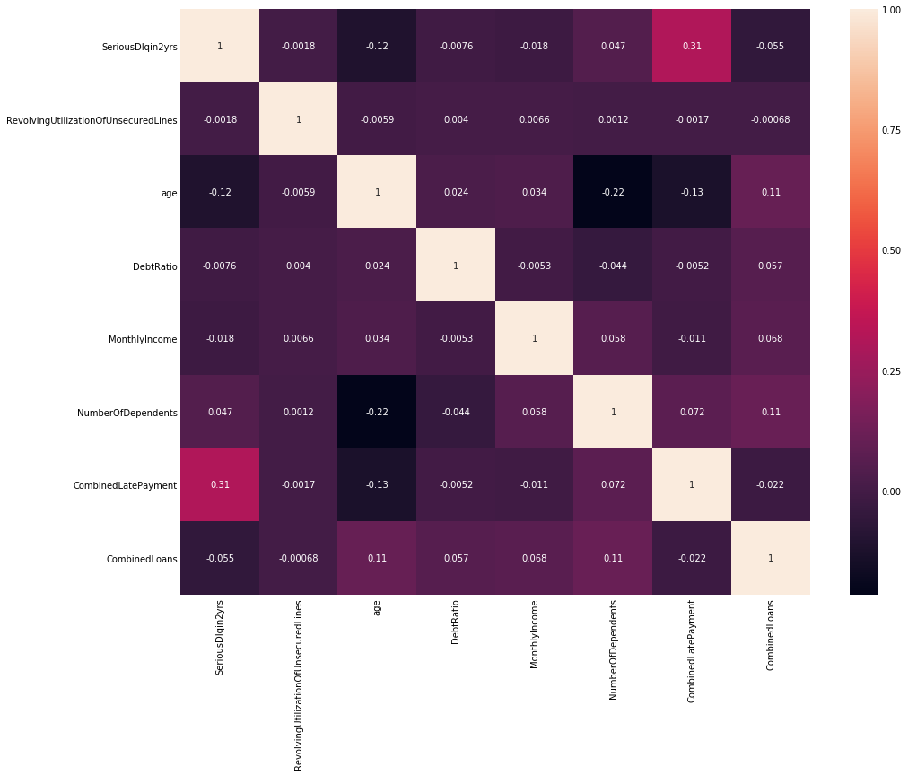

```python
corr = train_data.corr()
plt.figure(figsize=(14,12))
sns.heatmap(corr, annot=True, fmt=".2g")
```

```python
#Do modifications (cleaning) for Test Data as well
def cleaned_dataset(dataset):
    #age
    dataset.loc[dataset["age"] == 0, "age"] = dataset.age.median()

    #monthly income
    age_working = dataset.loc[(dataset["age"] >= 18) & (dataset["age"] < 60)]
    age_senior = dataset.loc[(dataset["age"] >= 60)]
    dataset["MonthlyIncome"] = dataset["MonthlyIncome"].fillna(99999) #to avoid TypeError
    dataset.loc[((dataset["age"] >= 18) & (dataset["age"] < 60)) & (dataset["MonthlyIncome"] == 99999), "MonthlyIncome"] = age_working.MonthlyIncome.mean()
    dataset.loc[(dataset["age"] >= 60) & (dataset["MonthlyIncome"] == 99999), "MonthlyIncome"] = age_senior.MonthlyIncome.mean()

    #number of dependents
    dataset["NumberOfDependents"] = dataset["NumberOfDependents"].fillna(0)
    dataset["NumberOfDependents"] = dataset["NumberOfDependents"].astype('int64')

    #combined late payments
    dataset["CombinedLatePayment"] = dataset["NumberOfTime30-59DaysPastDueNotWorse"] + dataset["NumberOfTimes90DaysLate"] + dataset["NumberOfTime60-89DaysPastDueNotWorse"]
    dataset.loc[(dataset["CombinedLatePayment"] >= 1), "CombinedLatePayment"] = 1

    #combined loans
    dataset["CombinedLoans"] = dataset["NumberOfOpenCreditLinesAndLoans"] + dataset["NumberRealEstateLoansOrLines"]
    dataset.loc[(dataset["CombinedLoans"] <= 5), "CombinedLoans"] = 0
    dataset.loc[(dataset["CombinedLoans"] > 5), "CombinedLoans"] = 1

    #dropping the old features
    dataset.drop(["NumberOfTime30-59DaysPastDueNotWorse", "NumberOfTimes90DaysLate", "NumberOfTime60-89DaysPastDueNotWorse", "NumberOfOpenCreditLinesAndLoans","NumberRealEstateLoansOrLines"], axis = 1, inplace = True)
```

```python
print('Details of modified Test Data are as below: ')
cleaned_dataset(test_data)
test_data.info()
```

```
Details of modified Test Data are as below:
<class 'pandas.core.frame.DataFrame'>
RangeIndex: 101503 entries, 0 to 101502
Data columns (total 8 columns):
SeriousDlqin2yrs                        0 non-null float64
RevolvingUtilizationOfUnsecuredLines    101503 non-null float64
age                                     101503 non-null float64
DebtRatio                               101503 non-null float64
MonthlyIncome                           101503 non-null float64
NumberOfDependents                      101503 non-null int64
CombinedLatePayment                     101503 non-null int64
CombinedLoans                           101503 non-null int64
dtypes: float64(5), int64(3)
memory usage: 6.2 MB
```

### Choice of Predictive Model

Imbalanced data generate models that are inclined to the dominant class of the output. Since data provided are highly imbalanced (only 6.68% event rate for training data), ensemble models such as Random Forest and Gradient Boosting will be used as they can force both Yes and No classes from SeriousDlqin2yrs to be addressed.

### Analysis on Model's Performance

The performance metric for this modelling is accuracy via AUC (area under the curve) of the ROC (receiver operating characteristic) curve.

```python
#Preparation
#import
from sklearn.model_selection import train_test_split, cross_val_predict
from sklearn.metrics import roc_curve, roc_auc_score
from sklearn.preprocessing import StandardScaler

X = train_data.drop("SeriousDlqin2yrs", axis=1).copy()
y = train_data.SeriousDlqin2yrs

X_test = test_data.drop("SeriousDlqin2yrs", axis=1).copy()
y_test = test_data.SeriousDlqin2yrs

X_train, X_val, y_train, y_val = train_test_split(X,y,random_state=42)

#roc curve
def plot_roc_curve(fpr, tpr, label=None):
    plt.figure(figsize=(12,10))
    plt.plot(fpr, tpr, linewidth=2, label=label)
    plt.plot([0,1],[0,1], "k--")
    plt.axis([0,1,0,1])
    plt.xlabel("False Positive Rate")
    plt.ylabel("True Positive rate")
```

#### Random Forest

Firstly, the maximum tree depth of 5 is assessed. Below are the AUC Score and ROC Curve of the corresponding random forest created from the Training Data and Test Data (cross validation) respectively:

```
AUC Score (Training) 0.8531585866581919
```

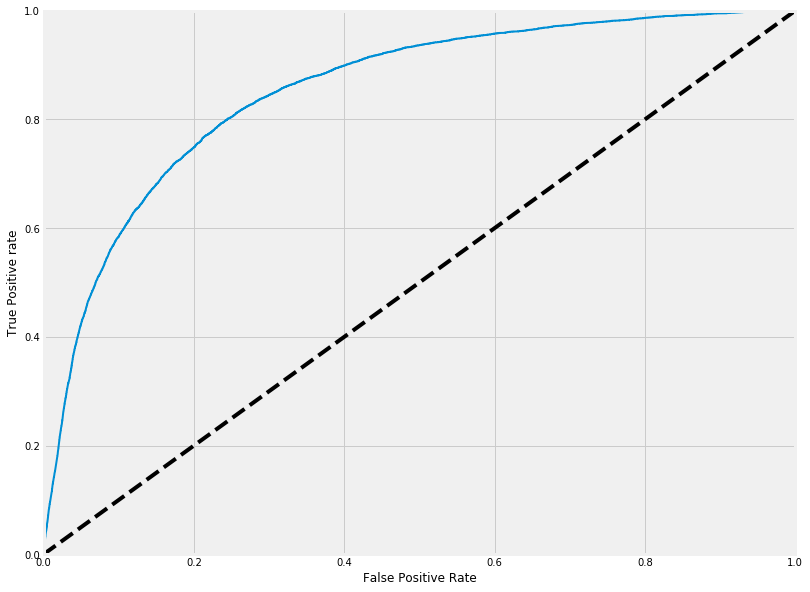

```python
#Random Forest
from sklearn.ensemble import RandomForestClassifier
forest = RandomForestClassifier(random_state=42,n_estimators=300, max_depth=5, class_weight="balanced")
forest.fit(X_train,y_train)
y_scores_proba = forest.predict_proba(X_train)
y_scores = y_scores_proba[:,1]
fpr, tpr, thresh = roc_curve(y_train, y_scores)
plot_roc_curve(fpr,tpr)
print("AUC Score (Training) {}".format(roc_auc_score(y_train,y_scores)))
```

```
AUC Score (Validation) 0.8487555699752702
```

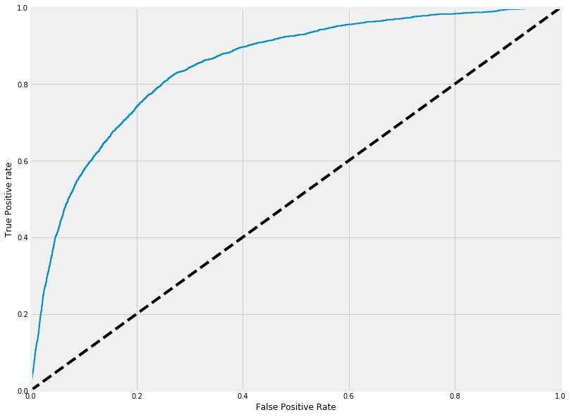

```python
#Cross validation
y_val_proba = forest.predict_proba(X_val)
y_scores_val = y_val_proba[:,1]
fpr_val, tpr_val, thresh_val = roc_curve(y_val, y_scores_val)
plot_roc_curve(fpr_val,tpr_val)
print("AUC Score (Validation) {}".format(roc_auc_score(y_val,y_scores_val)))
```

Taking a look at other maximum tree depths,

| Max depth | AUC Score (Training) | AUC Score (Validation) |
| --- | --- | --- |
| 4 | 0.8497 | 0.8471 |
| 5 | 0.8532 | 0.8488 |
| 6 | 0.8576 | 0.8504 |
| 7 | 0.8636 | 0.8514 |
| 8 | 0.8712 | 0.8518 |
| 9 | 0.8814 | 0.8513 |
| 10 | 0.8934 | 0.8507 |
| 11 | 0.9080 | 0.8492 |
| 12 | 0.9230 | 0.8472 |

The table suggests that maximum three depth of 8 is optimum (highest AUC Score on Test Data), whereas any tree deeper than that shows overfitting. Next step is to examine the feature importance of this random forest model.

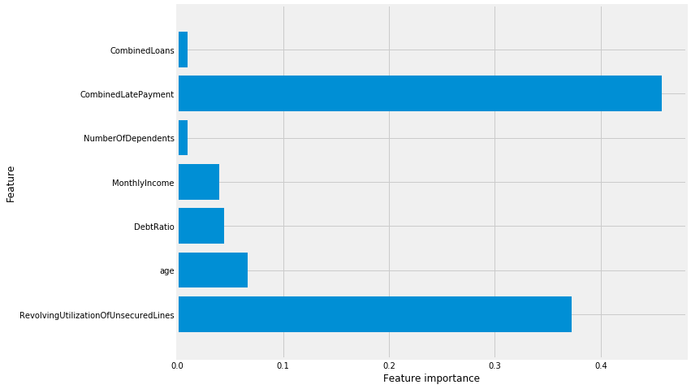

```python
#Feature importance
def plot_feature_importances(model):
    plt.figure(figsize=(10,8))
    n_features = X.shape[1]
    plt.barh(range(n_features), model.feature_importances_, align='center')
    plt.yticks(np.arange(n_features), X.columns)
    plt.xlabel("Feature importance")
    plt.ylabel("Feature")
    plt.ylim(-1, n_features)

forest_modif = RandomForestClassifier(random_state=42,n_estimators=300, max_depth=8, class_weight="balanced")
forest_modif.fit(X_train,y_train)
plot_feature_importances(forest_modif)
```

It can be observed that the Random Forest algorithm puts much importance to CombinedLatePayment and RevolvingUtilizationOfUnsecuredLines while neglecting the other features. This suggests that the Random Forest might not be an appropriate model for these credit scoring datasets.

#### Gradient Boosting

As a starting point, Gradient Boosting is performed with 300 boosting stages, 0.05 learning rate, and maximum depth of individual regression estimators of 8.

```
AUC Score (Training) 0.9351437801424934
```

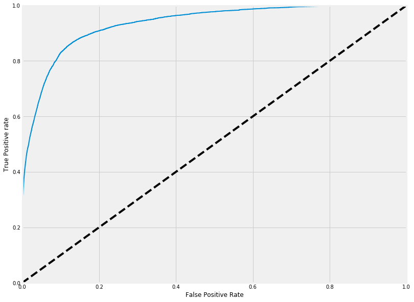

```python
#GradientBoostingClassifier
from sklearn.ensemble import GradientBoostingClassifier
gbc_clf = GradientBoostingClassifier(n_estimators=300, learning_rate=0.05, max_depth=8, random_state=42)
gbc_clf.fit(X_train,y_train)
gbc_clf_proba = gbc_clf.predict_proba(X_train)
gbc_clf_scores = gbc_clf_proba[:,1]
fpr_gbc, tpr_gbc, thresh_gbc = roc_curve(y_train, gbc_clf_scores)
plot_roc_curve(fpr_gbc, tpr_gbc)
print("AUC Score (Training) {}".format(roc_auc_score(y_train, gbc_clf_scores)))
```

```python
#Cross validation
gbc_val_proba = gbc_clf.predict_proba(X_val)
gbc_val_scores = gbc_val_proba[:,1]
print("AUC Score (Validation) {}".format(roc_auc_score(y_val, gbc_val_scores)))
```

```
AUC Score (Validation) 0.8491379058248437
```

The far higher training AUC score indicates overfitting. Hence, number of boosting stages and estimators' maximum depth are reduced (in this case, to 200 and 4 respectively).

```python
#Overfitting analysis
gbc_clf_modif = GradientBoostingClassifier(n_estimators=200, learning_rate=0.05 ,max_depth=4,  random_state=42)
gbc_clf_modif.fit(X_train,y_train)
gbc_clf_proba = gbc_clf_modif.predict_proba(X_train)
gbc_clf_scores = gbc_clf_proba[:,1]
gbc_val_proba = gbc_clf_modif.predict_proba(X_val)
gbc_val_scores = gbc_val_proba[:,1]
fpr_gbc, tpr_gbc, thresh_gbc = roc_curve(y_train, gbc_clf_scores)
print("AUC Score (Training){}".format(roc_auc_score(y_train, gbc_clf_scores))), print("AUC Score (Validation) {}".format(roc_auc_score(y_val, gbc_val_scores)))
```

```
AUC Score (Training)0.8636399765639553
AUC Score (Validation) 0.8528907807554489
```

```
(None, None)
```

The feature importance chart of the performed Gradient Boosting is as follows:

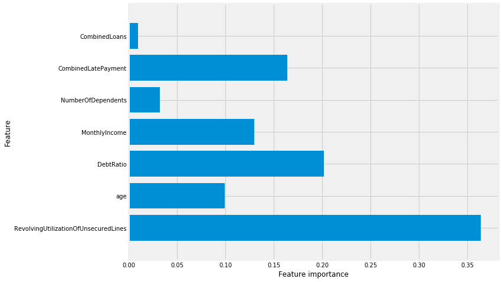

```python
#Feature importance
plot_feature_importances(gbc_clf_modif)
```

Contrary to the Random Forest, importance put by the Gradient Boosting model is more balanced throughout all variables.

## 4. Conclusion

Gradient Boosting with 200 steps, maximum depth of 4, and learning rate of 0.05 is then selected as a model for the Credit Scoring Algorithm. The outlook of the final model applied to the test data is as follows:

```python
final_proba = gbc_clf_modif.predict_proba(X_test)
final_scores = final_proba[:,1]

test_data_final = test_data.copy()
test_data_final['SeriousDlqin2yrs'] = final_scores
test_data_final
```

|  | SeriousDlqin2yrs | RevolvingUtilizationOfUnsecuredLines | age | DebtRatio | MonthlyIncome | NumberOfDependents | CombinedLatePayment | CombinedLoans |
| --- | --- | --- | --- | --- | --- | --- | --- | --- |
| 0 | 0.071016 | 0.885519 | 43.0 | 0.177513 | 5700.000000 | 0 | 0 | 0 |
| 1 | 0.040307 | 0.463295 | 57.0 | 0.527237 | 9141.000000 | 2 | 0 | 1 |
| 2 | 0.016453 | 0.043275 | 59.0 | 0.687648 | 5083.000000 | 2 | 0 | 1 |
| 3 | 0.157108 | 0.280308 | 38.0 | 0.925961 | 3200.000000 | 0 | 1 | 1 |
| 4 | 0.120246 | 1.000000 | 27.0 | 0.019917 | 3865.000000 | 1 | 0 | 0 |
| 5 | 0.025747 | 0.509791 | 63.0 | 0.342429 | 4140.000000 | 1 | 0 | 0 |
| 6 | 0.041185 | 0.587778 | 50.0 | 1048.000000 | 0.000000 | 3 | 0 | 0 |
| 7 | 0.076910 | 0.046149 | 79.0 | 0.369170 | 3301.000000 | 1 | 1 | 1 |
| 8 | 0.013247 | 0.013527 | 68.0 | 2024.000000 | 7474.192582 | 0 | 0 | 0 |
| 9 | 0.277051 | 1.000000 | 23.0 | 0.000000 | 0.000000 | 0 | 1 | 0 |
| 10 | 0.013110 | 0.028485 | 37.0 | 0.319687 | 7400.000000 | 1 | 0 | 1 |
| 11 | 0.021441 | 0.085077 | 52.0 | 0.903552 | 4250.000000 | 0 | 0 | 1 |
| 12 | 0.008029 | 0.010596 | 68.0 | 0.007782 | 3854.000000 | 0 | 0 | 1 |
| 13 | 0.041533 | 0.380679 | 30.0 | 0.377449 | 2500.000000 | 1 | 0 | 1 |
| 14 | 0.050730 | 0.556894 | 56.0 | 0.697347 | 6822.000000 | 1 | 0 | 1 |
| 15 | 0.016639 | 0.079056 | 28.0 | 0.105831 | 7133.000000 | 0 | 0 | 1 |
| 16 | 0.030817 | 0.543013 | 72.0 | 0.461786 | 5900.000000 | 1 | 0 | 1 |
| 17 | 0.015601 | 0.112346 | 37.0 | 0.144326 | 2916.000000 | 0 | 0 | 1 |
| 18 | 0.250618 | 0.648285 | 29.0 | 0.174850 | 4500.000000 | 1 | 1 | 0 |
| 19 | 0.079155 | 0.686406 | 43.0 | 487.000000 | 6596.628563 | 1 | 0 | 1 |
| 20 | 0.011291 | 0.085910 | 48.0 | 0.196156 | 8844.000000 | 1 | 0 | 1 |
| 21 | 0.014731 | 0.158549 | 61.0 | 0.353158 | 11920.000000 | 0 | 0 | 1 |
| 22 | 0.008484 | 0.009303 | 69.0 | 0.384451 | 6083.000000 | 0 | 0 | 1 |
| 23 | 0.360859 | 0.957442 | 69.0 | 0.666338 | 3041.000000 | 1 | 1 | 1 |
| 24 | 0.116347 | 0.442489 | 50.0 | 0.286555 | 8500.000000 | 2 | 1 | 1 |
| 25 | 0.014064 | 0.125267 | 51.0 | 3825.000000 | 6596.628563 | 0 | 0 | 1 |
| 26 | 0.093534 | 1.000000 | 45.0 | 0.000000 | 4750.000000 | 1 | 0 | 0 |
| 27 | 0.029464 | 0.181481 | 67.0 | 1509.000000 | 7474.192582 | 0 | 0 | 1 |
| 28 | 0.062799 | 0.729397 | 34.0 | 0.335555 | 7500.000000 | 1 | 0 | 1 |
| 29 | 0.013360 | 0.024445 | 47.0 | 5810.000000 | 6596.628563 | 2 | 0 | 1 |
| ... | ... | ... | ... | ... | ... | ... | ... | ... |
| 101473 | 0.028955 | 0.662634 | 73.0 | 0.277090 | 5333.000000 | 0 | 0 | 1 |
| 101474 | 0.462674 | 1.032484 | 47.0 | 0.365243 | 2036.000000 | 0 | 1 | 0 |
| 101475 | 0.094286 | 1.000000 | 35.0 | 0.240467 | 1284.000000 | 2 | 0 | 0 |
| 101476 | 0.007234 | 0.015908 | 68.0 | 0.217593 | 8400.000000 | 1 | 0 | 1 |
| 101477 | 0.007988 | 0.096295 | 69.0 | 0.052316 | 3000.000000 | 0 | 0 | 0 |
| 101478 | 0.014532 | 0.000000 | 43.0 | 0.095303 | 5833.000000 | 2 | 0 | 1 |
| 101479 | 0.072216 | 0.024788 | 71.0 | 0.361319 | 3608.000000 | 0 | 1 | 1 |
| 101480 | 0.027624 | 0.217134 | 48.0 | 0.602701 | 5257.000000 | 0 | 0 | 1 |
| 101481 | 0.011248 | 0.048971 | 51.0 | 0.339154 | 7043.000000 | 2 | 0 | 1 |
| 101482 | 0.460267 | 1.000000 | 33.0 | 0.000000 | 2000.000000 | 3 | 1 | 0 |
| 101483 | 0.008770 | 0.124484 | 82.0 | 0.003797 | 7636.000000 | 0 | 0 | 0 |
| 101484 | 0.008479 | 0.065636 | 60.0 | 0.306759 | 7500.000000 | 1 | 0 | 1 |
| 101485 | 0.006737 | 0.043139 | 81.0 | 0.014548 | 3917.000000 | 0 | 0 | 0 |
| 101486 | 0.015470 | 0.078280 | 55.0 | 0.495979 | 2983.000000 | 1 | 0 | 1 |
| 101487 | 0.013636 | 0.000961 | 64.0 | 2.000000 | 7474.192582 | 0 | 0 | 0 |
| 101488 | 0.011906 | 0.179587 | 68.0 | 0.268839 | 7550.000000 | 0 | 0 | 1 |
| 101489 | 0.193008 | 1.031359 | 34.0 | 0.305339 | 3333.000000 | 1 | 0 | 1 |
| 101490 | 0.308810 | 0.875649 | 43.0 | 0.512893 | 9500.000000 | 2 | 1 | 1 |
| 101491 | 0.100544 | 0.228665 | 44.0 | 0.080143 | 8958.000000 | 0 | 1 | 1 |
| 101492 | 0.105406 | 0.139191 | 58.0 | 3.183267 | 501.000000 | 3 | 1 | 1 |
| 101493 | 0.008488 | 0.035549 | 58.0 | 0.290323 | 11128.000000 | 2 | 0 | 1 |
| 101494 | 0.014176 | 0.218356 | 56.0 | 0.295803 | 1500.000000 | 0 | 0 | 0 |
| 101495 | 0.248793 | 0.718874 | 35.0 | 0.308047 | 4125.000000 | 2 | 1 | 1 |
| 101496 | 0.023037 | 0.021654 | 78.0 | 18.000000 | 7474.192582 | 0 | 0 | 1 |
| 101497 | 0.007075 | 0.045230 | 67.0 | 0.012198 | 5000.000000 | 0 | 0 | 0 |
| 101498 | 0.024637 | 0.282653 | 24.0 | 0.068522 | 1400.000000 | 0 | 0 | 0 |
| 101499 | 0.413707 | 0.922156 | 36.0 | 0.934217 | 7615.000000 | 4 | 1 | 1 |
| 101500 | 0.017032 | 0.081596 | 70.0 | 836.000000 | 7474.192582 | 0 | 0 | 0 |
| 101501 | 0.095903 | 0.335457 | 56.0 | 3568.000000 | 6596.628563 | 3 | 1 | 1 |
| 101502 | 0.034263 | 0.441842 | 29.0 | 0.198918 | 5916.000000 | 0 | 0 | 1 |

101503 rows × 8 columns

The closer the value of SeriousDlqin2yrs to 0, the less the probability of default. Conversely, SeriousDlqin2yrs of closer to 1 implies more probability of default and hence more discretion should be exercised.